# Machine Learning - 1

Dmindemon

October 24, 2015

# Overview

Using devices such as Jawbone Up, Nike FuelBand, and Fitbit it is now possible to collect a large amount of data about personal activity relatively inexpensively. These type of devices are part of the quantified self movement – a group of enthusiasts who take measurements about themselves regularly to improve their health, to find patterns in their behavior, or because they are tech geeks. One thing that people regularly do is quantify how much of a particular activity they do, but they rarely quantify how well they do it. In this project, your goal will be to use data from accelerometers on the belt, forearm, arm, and dumbell of 6 participants. They were asked to perform barbell lifts correctly and incorrectly in 5 different ways.

The goal of this project is to predict the manner in which they did the exercise. This is the “classe” variable in the training set.

# Preprocessing

Load the data:

```r
download.file("https://d396qusza40orc.cloudfront.net/predmachlearn/pml-training.csv",'train.csv',method='curl')
test <- read.csv("test.csv")
download.file("https://d396qusza40orc.cloudfront.net/predmachlearn/pml-testing.csv",'test.csv',method='curl')
train <- read.csv("train.csv")
```

Remove varables with zero covariates

```r
set.seed(100)
library(caret)
library(RANN)
library(rpart)
nsv <- nearZeroVar(train, saveMetrics=TRUE)
remove_var <- rownames(nsv)[!(nsv$nzv==TRUE)]
train_nonzv <- train[,remove_var]
```

Deal with NA value: Remove column with NA larger than 30%.

```r
a <- c()
nrow <- nrow(train_nonzv)
for (i in 1:100){
    if (sum(is.na(train_nonzv[,i]))/nrow > 0.3){
        a <- c(i,a)
    }
}
train_nonzv <- train_nonzv[,-a]
```

Using k nearest impute NA value.

```r
train_numeric <- train_nonzv[,sapply(train_nonzv, is.numeric)]
preObj <- preProcess(train_numeric, method=c("knnImpute"))
newtrain_numeric <- predict(preObj, train_numeric)
train_char <- train_nonzv[,!(sapply(train_nonzv, is.numeric))]
training <- as.data.frame(cbind(train_char, newtrain_numeric))
```

We don’t need the time data and X.

```r
training <- training[,-c(2,4)]
```

Also in the test set, some variables are totally missing. We can’t build model with those missing variables.

```r
names_NA_test <- names(test)[sapply(test[1,],is.na)]
training <- training[,!(names(training) %in% names_NA_test)]
```

# Modeling

First, let’s look at the dependent variable.

```r
summary(training$classe)
```

```
##    A    B    C    D    E
## 5580 3797 3422 3216 3607
```

Since the result is categorical, we can use classification tree with cross-validation.

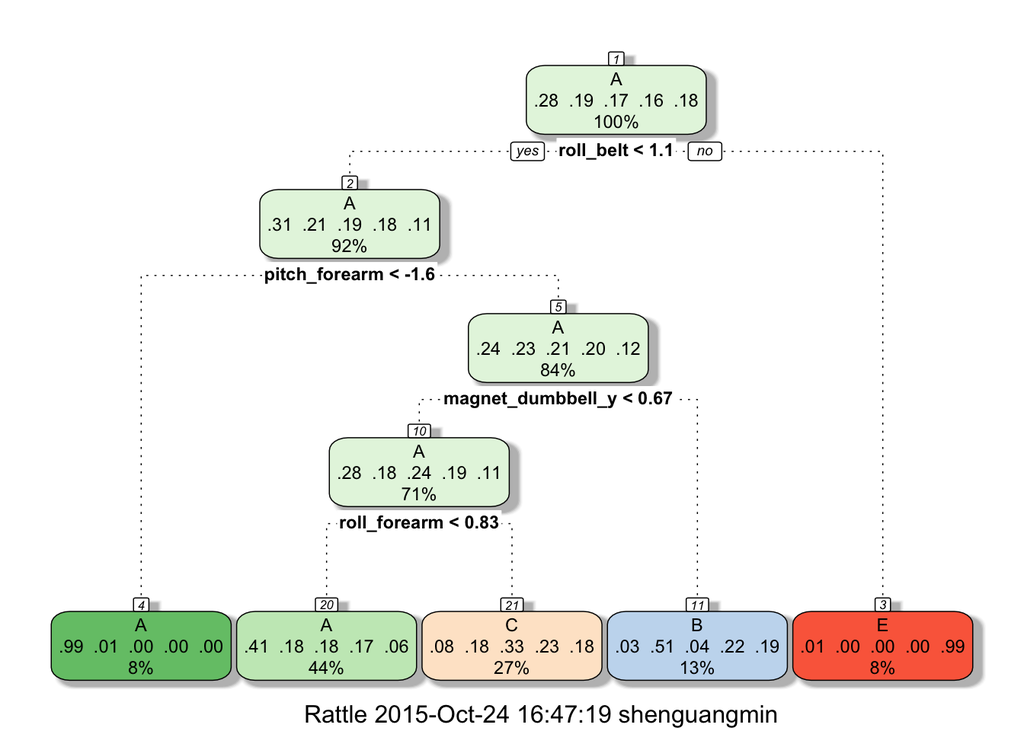

```r
train_control <- trainControl(method='cv', number=7)
fit <- train(classe~., data=training, trControl=train_control, method='rpart')
library(rattle)
fancyRpartPlot(fit$finalModel)
```

```r
confusionMatrix(predict(fit,training), training$classe)
```

```
## Confusion Matrix and Statistics
##
##           Reference
## Prediction    A    B    C    D    E
##          A 5080 1581 1587 1449  524
##          B   81 1286  108  568  486
##          C  405  930 1727 1199  966
##          D    0    0    0    0    0
##          E   14    0    0    0 1631
##
## Overall Statistics
##
##                Accuracy : 0.4956
##                  95% CI : (0.4885, 0.5026)
##     No Information Rate : 0.2844
##     P-Value [Acc > NIR] : < 2.2e-16
##
##                   Kappa : 0.3407
##  Mcnemar's Test P-Value : NA
##
## Statistics by Class:
##
##                      Class: A Class: B Class: C Class: D Class: E
## Sensitivity            0.9104  0.33869  0.50468   0.0000  0.45218
## Specificity            0.6339  0.92145  0.78395   1.0000  0.99913
## Pos Pred Value         0.4970  0.50850  0.33040      NaN  0.99149
## Neg Pred Value         0.9468  0.85310  0.88225   0.8361  0.89008
## Prevalence             0.2844  0.19351  0.17440   0.1639  0.18382
## Detection Rate         0.2589  0.06554  0.08801   0.0000  0.08312
## Detection Prevalence   0.5209  0.12889  0.26638   0.0000  0.08383
## Balanced Accuracy      0.7721  0.63007  0.64431   0.5000  0.72565
```

# Predicting

```r
testing <- test[,names(test) %in% names(training)]
result <- as.data.frame(rbind(as.vector(predict(fit,newdata=testing))))
names(result) <- testing[,1]
result
```

```
##   pedro jeremy jeremy adelmo eurico jeremy jeremy jeremy carlitos charles
## 1     E      A      A      E      E      B      E      B        A       E
##   carlitos jeremy eurico jeremy jeremy eurico pedro carlitos pedro eurico
## 1        A      A      B      A      E      E     E        B     E      E
```